# Assignment 5

Yedhu Sanil Kumar

10/16/2021

### Enhancing the productivity of hybrid Poplar (Populus× hybrid) and Switchgrass (Panicum virgatum L.) by the application of beneficial soil microbes and a seaweed extract.

Fei, H., Crouse, M., Papadopoulos, Y., & Vessey, J. K. (2017). Enhancing the productivity of hybrid Poplar (Populus× hybrid) and Switchgrass (Panicum virgatum L.) by the application of beneficial soil microbes and a seaweed extract. Biomass and bioenergy, 107, 122-134.

https://github.com/Yedhu89/Assisgnment_5_Yedhu.git

#### Introduction:

The study by Fei et al.,(2017) carries out an investigation on the effects of three beneficial soil microbes Azospirillum brasilense, Pencillium bilaii, Variovorax paradoxus, and Ascophyllum nodosum (Seaweed) tested on the growth of three clones of hybrid poplars and two cultivars of Switchgrass grown under greenhouse conditions and on marginal land. Good quality and high yielding feedstocks on marginal lands with low inputs could help lower costs.Beneficial soil microbes have many advantages to plants like enhanced growth, at low costs (Vessey, J. K. 2003). Inoculating biofuel feedstock crop species with such microbes can increase the productivity and lower the costs of biofuel feedstocks.This experiment was done to enhance to yield and productivity of the biomass crops by the application of beneficial soil microbes and a seaweed. The application of beneficial soil microbes and plant supplements enhances productivity of biomass feedstocks and help lower cost of biofuel.

#### Methods:

Three poplar clones and two cultivars of switchgrass were selcted for the experiment. The hybrid poplar clones were Hill, Okanese and Walker from the Agriculture and Agri-Food Canada (AAFC) Saskatchewan.The switchgrass cultivars were a wild type and the cultivar ‘Cave-In-Rock’. The plants were grown in both greenhouse and field to evaluate the treatment effects and were treated with soil microbes and seaweed extract (A.nodosum). After 1 month of growth, each plant was inoculated with 2 ml of bacterial broth (108 cfu ml−1), and 1 ml of ANE by soil drenching. After 3 months of growth, poplar stems, leaves and roots, and switchgrass shoots and roots were harvested separately, and each plant sample was ground into a fine powder for nutrient analyses. Concentrations of Nitrogen (N), Phosphorus (P) and Potassium (K) in the tissues were determined by Laboratory Service, Department of Agriculture, Nova Scotia.

#### Results:

The plants were harvested after 3 months of growth from both setting. The results show that Biomass in poplar cultivars like Okanese and Walker under both conditions was high in treatments with A.brasilense and P. bilaii by 23% and 26%. There were no treatment effects in clone ‘Hill’, thereby indicating a genotype-specific effect. For switchgrass, Biomass in ‘Cave-In-Rock’ under greenhouse inoculated with A. brasilense or P. bilaii was higher by 18% compared to other treatments, but there were no significant increases in the field trials. No treatments effects on biomass in the Wildtype, again indicating a genotype-specific effect.

#### Conclusion:

The finals results concluded that under both the greenhouse and field growth conditions, suggest that in some cases A. brasilense N8 and P. bilaii can enhance growth and/or nutrient accumulation of hybrid poplar clone ‘Okanese’ and clone ‘Walker’ and switchgrass cv. ‘Cave-In-Rock’. Although less conclusive, there is also some evidence of positive effects of the A. nodosum extract on the growth and nutrient content in poplar. The results from the both the greenhouse and field shows A. brasilense N8 and P. bilaii can increase growth and nutrient accumulation for poplar clones ‘Okanese’ and ‘Walker’ and for switchgrass ‘Cave-In-Rock’. This approach may enable a more sustainable production of the biomass feedstock crops on marginal soils where no nutrient supply and periodic drought are present. This also helps to reduce the cost for Biofuel production.

#### Graphs

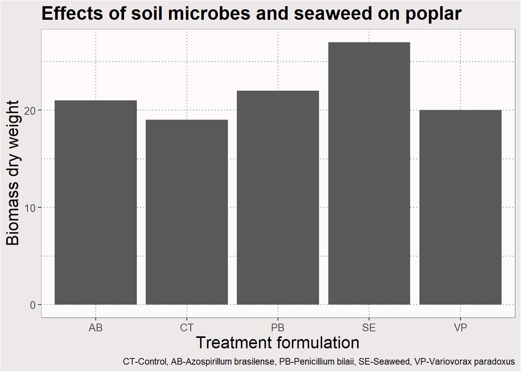

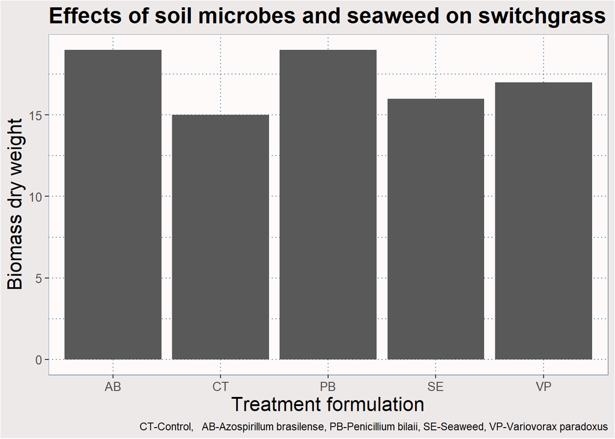

#### References:

Vessey, J. K. (2003). Plant growth promoting rhizobacteria as biofertilizers. Plant and soil, 255(2), 571-586.

Fei, H., Crouse, M., Papadopoulos, Y., & Vessey, J. K. (2017). Enhancing the productivity of hybrid poplar (Populus× hybrid) and switchgrass (Panicum virgatum L.) by the application of beneficial soil microbes and a seaweed extract. Biomass and bioenergy, 107, 122-134.

Hoagland, D. R., & Arnon, D. I. (1950). The water-culture method for growing plants without soil. Circular. California agricultural experiment station, 347(2nd edit).